# The **satdad** R package: Version 1.1.0 Vignette

## 2.3 Measures and plots of the tail dependence

The tail dependence is completely characterized by the stdf $\ell$, or equivalently by the `ds` object in this package. Summaries and graphical tools are obviously appreciated.

Well known extremal coefficients (ec), introduced by Tiago de Oliveira, J. (1962/63) and Smith (1990), are available in `satdad`. However, the focus is on the tail superset importance coefficients, which were introduced in Mercadier and Roustant (2019) and upper bounded in Mercadier and Ressel (2021). We believe that they also offer an interesting perspective on the description of the structure of the stable tail dependence function.

The theoretical functional decomposition of the variance of the stdf $\ell$ consists in writing
$$D(\ell) = \sum_{I \subseteq \{1,...,d\}}
D_I(\ell)$$
where $D_I(\ell)$ measures the variance of $\ell_I(U_I)$ the term associated with subset $I$ in the Hoeffding-Sobol decomposition of $\ell$ ; note that $U_I$ represents a random vector with independent standard uniform entries. Fixing a subset of components $I$, the theoretical tail superset importance coefficient (tsic) is defined as
$$\Upsilon_I(\ell)=\sum_{J \supseteq I}
D_J(\ell)\;.$$
An integral representation of the superset importance coefficient is provided by Formula (9) of Liu and Owen (2006). See also Mercadier and Roustant (2019) for its use in the extreme value context. Thus, the tsic here is the value of $\Upsilon_I(\ell)$ obtained by Monte Carlo methods from the integral formula (3) in Mercadier and Roustant (2019).

```r
res.tsic5 <- tsic(ds5)
as.character(res.tsic5$subsets)
```

```
##  [1] "1:2"     "c(1, 3)" "c(1, 4)" "c(1, 5)" "2:3"     "c(2, 4)" "c(2, 5)"
##  [8] "3:4"     "c(3, 5)" "4:5"
```

```r
res.tsic5$tsic
```

```
##  [1] 1.320186e-32 7.768925e-04 1.393141e-32 9.174360e-33 1.591981e-04
##  [6] 3.699052e-04 1.729641e-03 9.495182e-04 8.504907e-33 7.775364e-33
```

The `graphs` function in `satdad` implements the methodology introduced in Mercadier and Roustant (2019). The default option `which = taildependograph` draws the PAIRWISE tsic in a graphical representation called the tail dependograph. The command is as follows.

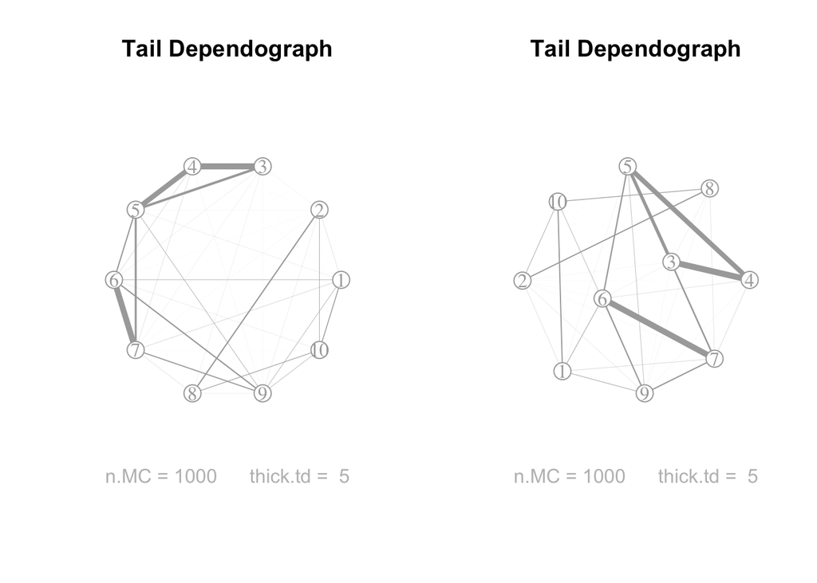

```r
oldpar <- par(mfrow=c(1,2))
graphs(ds10) # (left) the nodes are plotted on an invisible circle
graphs(ds10, random = TRUE) # (right) the position of the nodes are random
```

```r
par(oldpar)
```

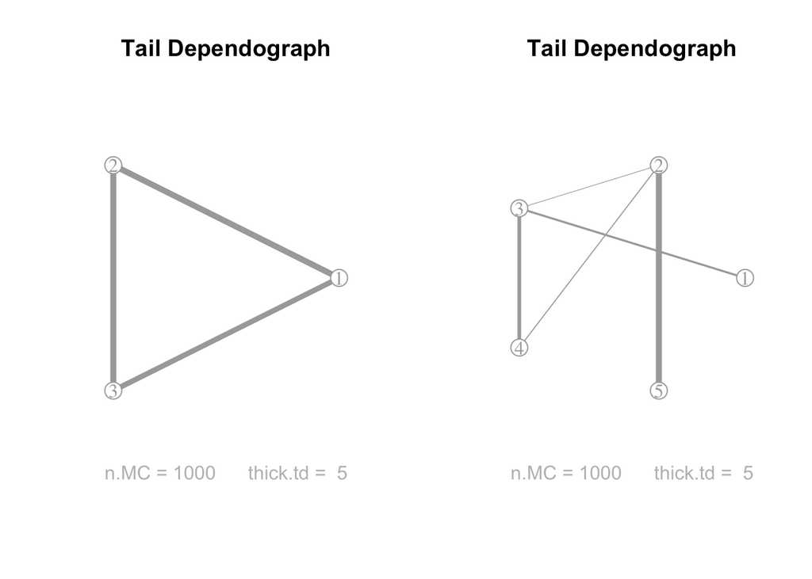

```r
oldpar <- par(mfrow=c(1,2))
graphs(ds3) # (left) the symmetric structure
graphs(ds5) # (right) the asymmetric structure contructed "manualy"
```

```r
par(oldpar)
```

A theoretical upper bound for tsic $\Upsilon_I(\ell)$ is given by Theorem 2 in Mercadier and Ressel (2021) which states that
$$\Upsilon_I(\ell)\leq
\frac{2(|I|!)^2}{(2|I|+2)!}$$
for any stdf $\ell$. This allows for meaningful comparison of these indices, regardless of the cardinality of $I$, using the expression
$$\dfrac{\Upsilon_I(\ell)}{D(\ell)}\times
\frac{(2|I|+2)!}{2(|I|!)^2}\;.$$
The option `sobol = TRUE` provides the renormalization by $D(\ell)$, while `norm = TRUE` multiplies by the inverse of the upper bound. The Cleveland dot plot is a useful tool to globally compare these coefficients.

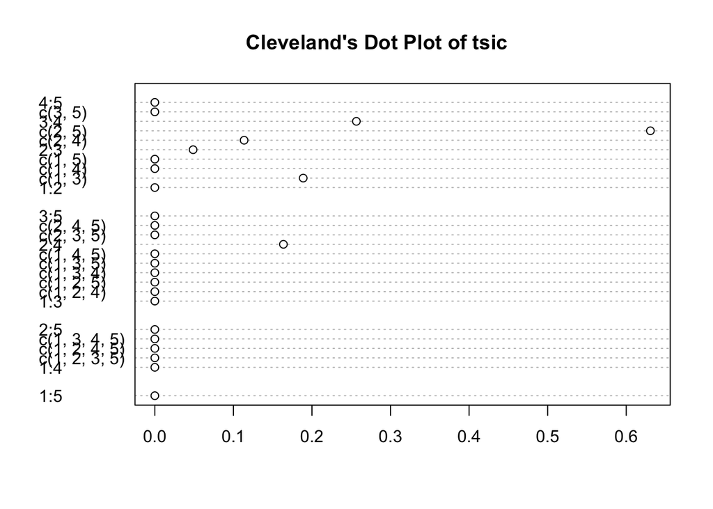

```r
plotClev(ds5)
```

The variance contribution $D_I(\ell)$ are referred to as the tail importance coefficient (tic) in this package, and should not be confused with the previously mentioned tsic, where “s” denotes supersets. The sobol version of tic, defined as
$$S_I(\ell)=\frac{D_I(\ell)}{D(\ell)}$$
can also be computed using this package.

```r
res.tic5 <- tic(ds5, ind = "with.singletons", sobol = TRUE)
sobol5 <- res.tic5$tic # which sum should be 1
```

Well known extremal coefficients (ec) can be computed and visualized as follows.

```r
res.ec10 <- ec(ds10)
as.character(res.ec10$subsets)
```

```
##  [1] "1:2"      "c(1, 3)"  "c(1, 4)"  "c(1, 5)"  "c(1, 6)"  "c(1, 7)"
##  [7] "c(1, 8)"  "c(1, 9)"  "c(1, 10)" "2:3"      "c(2, 4)"  "c(2, 5)"
## [13] "c(2, 6)"  "c(2, 7)"  "c(2, 8)"  "c(2, 9)"  "c(2, 10)" "3:4"
## [19] "c(3, 5)"  "c(3, 6)"  "c(3, 7)"  "c(3, 8)"  "c(3, 9)"  "c(3, 10)"
## [25] "4:5"      "c(4, 6)"  "c(4, 7)"  "c(4, 8)"  "c(4, 9)"  "c(4, 10)"
## [31] "5:6"      "c(5, 7)"  "c(5, 8)"  "c(5, 9)"  "c(5, 10)" "6:7"
## [37] "c(6, 8)"  "c(6, 9)"  "c(6, 10)" "7:8"      "c(7, 9)"  "c(7, 10)"
## [43] "8:9"      "c(8, 10)" "9:10"
```

```r
res.ec10$ec
```

```
##  [1] 1.728301 1.784605 1.773898 1.723167 1.579163 1.698211 2.000000 1.572147
##  [9] 1.782526 1.680999 1.771818 1.766987 1.769576 1.763550 1.780950 1.673925
## [17] 1.720529 1.423663 1.456121 1.742770 1.688921 1.894420 1.707623 1.908331
## [25] 1.394517 1.710018 1.706844 2.000000 1.739281 2.000000 1.573375 1.563603
## [33] 2.000000 1.651746 2.000000 1.465180 2.000000 1.507161 1.878091 1.876797
## [41] 1.540770 1.910424 1.905428 1.813186 1.767549
```

The option `which = "iecgraph"` in the `graphs` function of the package draws TWO minus the pairwise ec in a graphical representation.

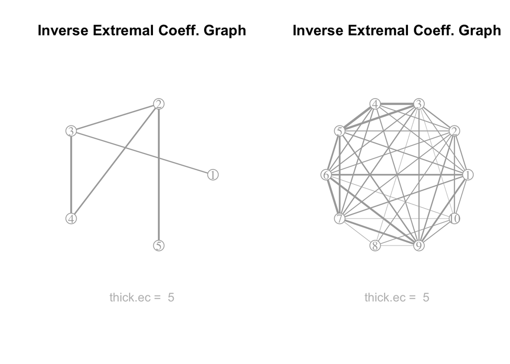

```r
oldpar <- par(mfrow=c(1,2))
graphs(ds5, which = "iecgraph")
graphs(ds10, which = "iecgraph")
```

```r
par(oldpar)
```

# 3. Empirical methods

The previous tail superset importance coefficients are computed by Monte Carlo approximation using the theoretical stable tail dependence function. When the latter is unknown, these indices are obtained from its non parametric estimation introduced by Huang (1992) in a bivariate setting and extended in de Haan and Resnick (1993).

Let ${\bf X}_1,...,{\bf X}_n$ be the `sample`, where each ${\bf X}_s$ is a $d$-dimensional vector $X_s^{(t)}$ for $t=1,...,d$.

Denote by $n$ the sample size, and fix $k$ as the threshold parameter.

Let $R^{(t)}_s$ denote the rank of $X^{(t)}_s$ among $X^{(t)}_1, ..., X^{(t)}_n$, and set $\overline{R}^{(t)}_s = \min((n- R^{(t)}_s+1)/k,1)$.

## 3.1 Basics

Proposition 1 and Theorem 2 of Mercadier and Roustant (2019) indeed provide several rank-based expressions. Non parametric estimations of $\Upsilon_I(\ell)$, $D(\ell)$, $D_I(\ell)$, and $S_I(\ell)$ are as follows:

$$\hat{\Upsilon}_{I,k,n}=\frac{1}{k^2}\sum_{s=1}^n\sum_{s^\prime=1}^n
\prod_{t\in
I}(\min(\overline{R}^{(t)}_s,\overline{R}^{(t)}_{s^\prime})-\overline{R}^{(t)}_{s}\overline{R}^{(t)}_{s^\prime})
\prod_{t\notin I}
\min(\overline{R}^{(t)}_s,\overline{R}^{(t)}_{s^\prime})$$

$$\hat{D}_{k,n}=\frac{1}{k^2}\sum_{s=1}^n\sum_{s^\prime=1}^n
\prod_{t\in I}\min(\overline{R}^{(t)}_s,\overline{R}^{(t)}_{s^\prime})-
\prod_{t\in
I}\overline{R}^{(t)}_{s}\overline{R}^{(t)}_{s^\prime}$$
$$\hat{D}_{I,k,n}=\frac{1}{k^2}\sum_{s=1}^n\sum_{s^\prime=1}^n
\prod_{t\in
I}(\min(\overline{R}^{(t)}_s,\overline{R}^{(t)}_{s^\prime})-\overline{R}^{(t)}_{s}\overline{R}^{(t)}_{s^\prime})
\prod_{t\notin I}
\overline{R}^{(t)}_s\overline{R}^{(t)}_{s^\prime}$$
and
$$\hat{S}_{I,k,n}=\dfrac{\hat{D}_{I,k,n}}{\hat{D}_{k,n}}\;.$$

The functions `tsic`, `graphs`, `plotClev`, `ec` and `tic` have thus an empirical counterpart, namely, `tsicEmp`, `graphsEmp`, `plotClevEmp`, `ecEmp` and `ticEmp`. The `graphsEmp` function has another version called `graphsMapEmp` when coordinates of the nodes are provided.

```r
res.ecEmp <- ecEmp(sample.ext, ind = "with.singletons", k = 100)
res.tsicEmp <- tsicEmp(sample.exp, ind = "all", k = 100)
res.ticEmp <- ticEmp(sample.gamma, ind = 4, k = 100)
```

The plots only are displayed.

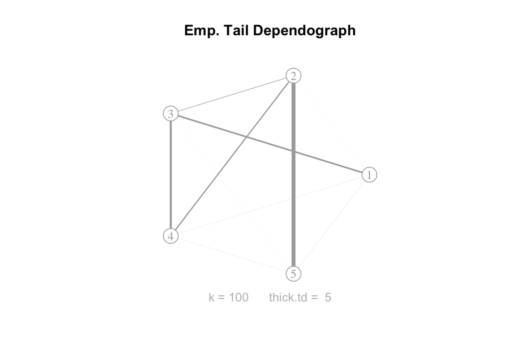

```r
graphsEmp(sample.ext, k = 100)
```

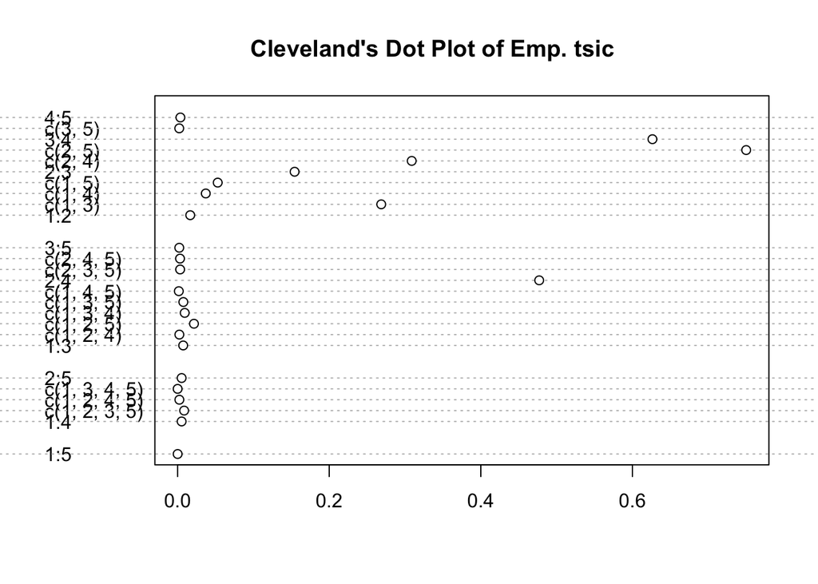

```r
plotClevEmp(sample.exp, ind = "all", k = 100)
```

## 3.2 The Danube dataset

The package `graphicalExtremes` implements the statistical methodology of Engelke and Hitz (2020), see also Asadi, Davison and Engelke (2015). The `danube` dataset in their package describes the river discharges for tributaries of the Danube.

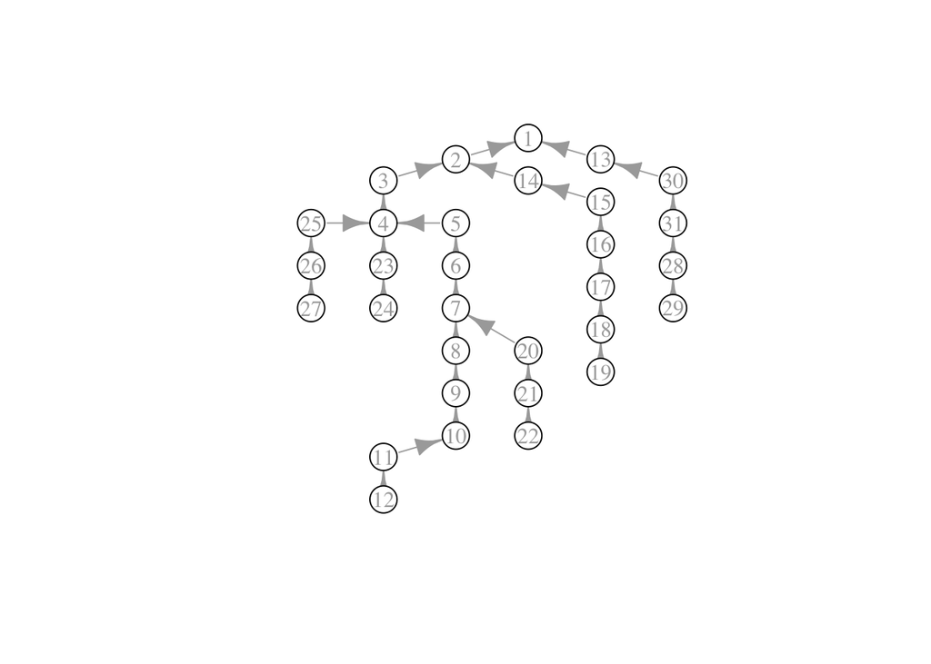

```r
library(graphicalExtremes)
g <- igraph::graph_from_edgelist(danube$flow_edges)
loc <- as.matrix(danube$info[,c('PlotCoordX', 'PlotCoordY')])
plot(g, layout = loc, vertex.color ="white", vertex.label.color = "darkgrey")
```

The tail dependence understood through the global sensibility analysis is now provided.

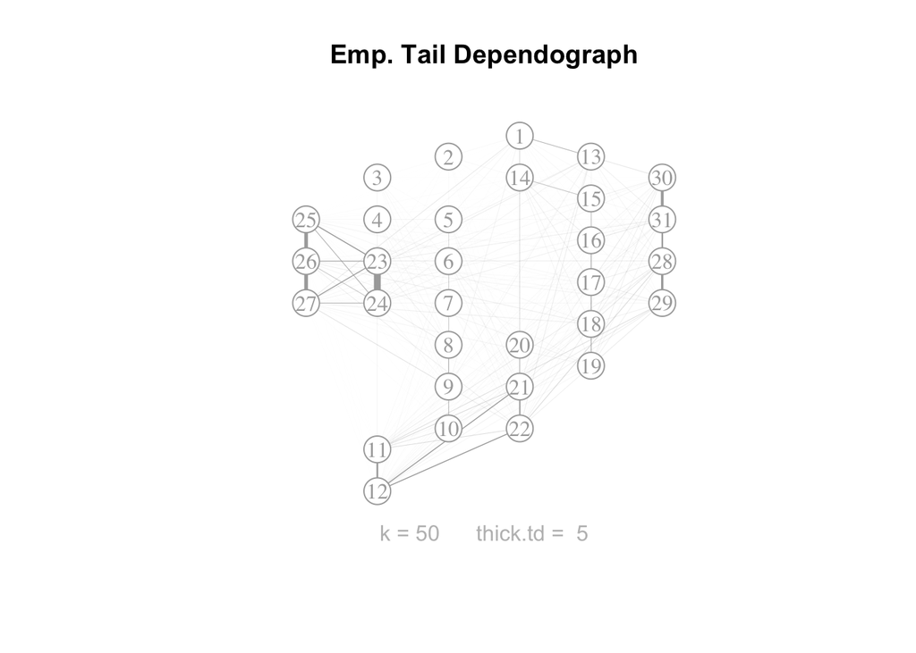

```r
dan <- danube$data_clustered
graphsEmp(dan,  k=50, layout = loc)
```

The representation is also given on a realistic map.

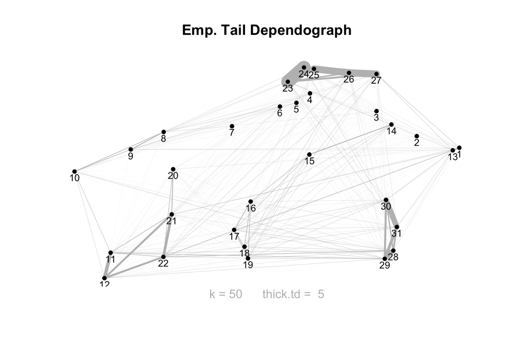

```r
lon <- as.numeric(unlist(danube$info[,"Long"]))
lat <- as.numeric(unlist(danube$info[,"Lat"]))*2
coord.dan <- list(lat = lat, lon = lon)
graphsMapEmp(dan, region = NULL, coord = coord.dan, k = 50, eps = 0.1)
```

A global comparison of the pairwise empirical tail superset importance coefficients is given by the empirical Cleveland’s dot plot of the sample.

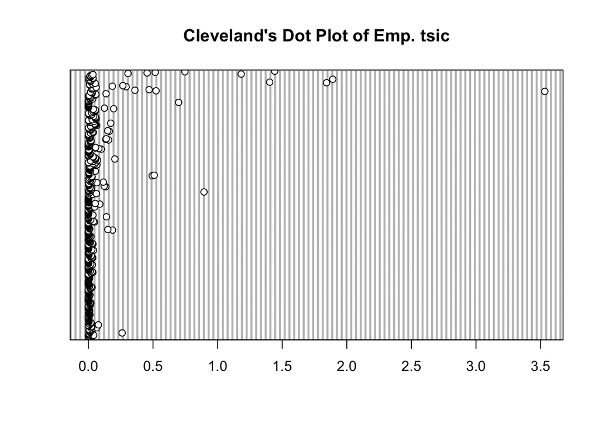

```r
plotClevEmp(dan,  k = 50,  ind = 2, labels = FALSE)
```

Observing the largest points, we focus on the largest below.

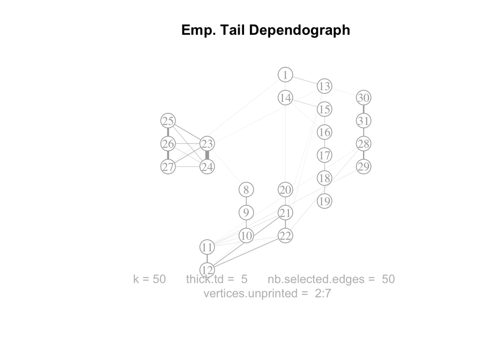

```r
graphsEmp(dan,  k=50, layout = loc, select = 50, simplify = TRUE)
```

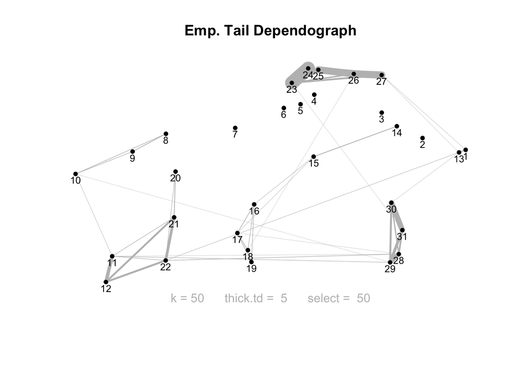

```r
graphsMapEmp(dan, region = NULL, coord = coord.dan, k = 50, select = 50, eps = 0.1)
```

Graphs based on inverse extremal coefficients can also be obtained by adding the option `which = "iecgraph"`.

## 3.3 Other datasets

We provide below some figures from Mercadier and Roustant (2019), first about temperatures (`France` dataset) and then log returns then (`Stock` dataset).

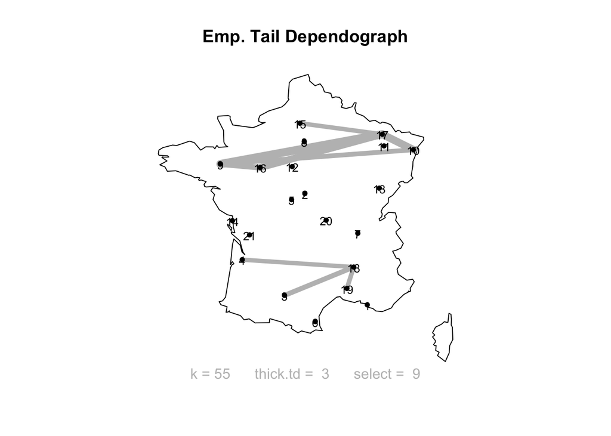

```r
 ## Figure 9 (a) of Mercadier  and Roustant (2019).
graphsMapEmp(sample = France$ymt, k = 55,
        coord = France$coord,  region = 'France', thick.td = 3, select = 9)
```

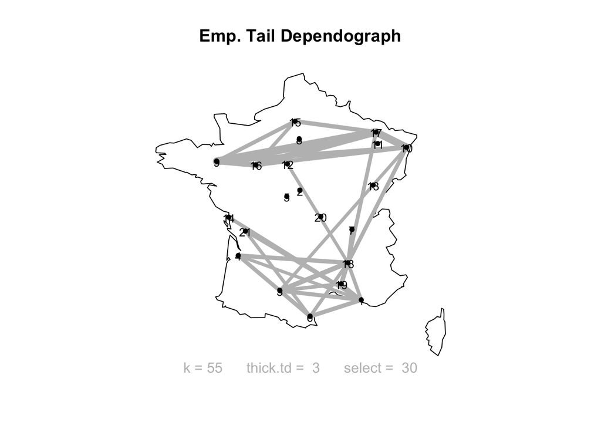

```r
## Figure 9 (b) of Mercadier  and Roustant (2019).
graphsMapEmp(sample = France$ymt, k = 55,
        coord = France$coord,  region = 'France', thick.td = 3, select = 30)
```

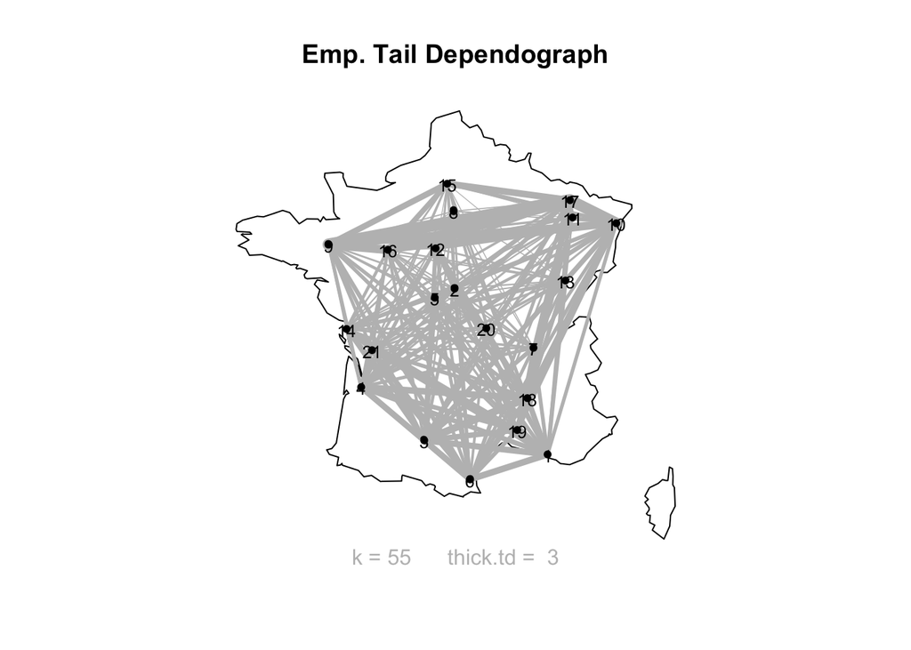

```r
## Figure 9 (c) of Mercadier  and Roustant (2019).
graphsMapEmp(sample = France$ymt, k = 55,
      coord = France$coord,  region = 'France', thick.td = 3)
```

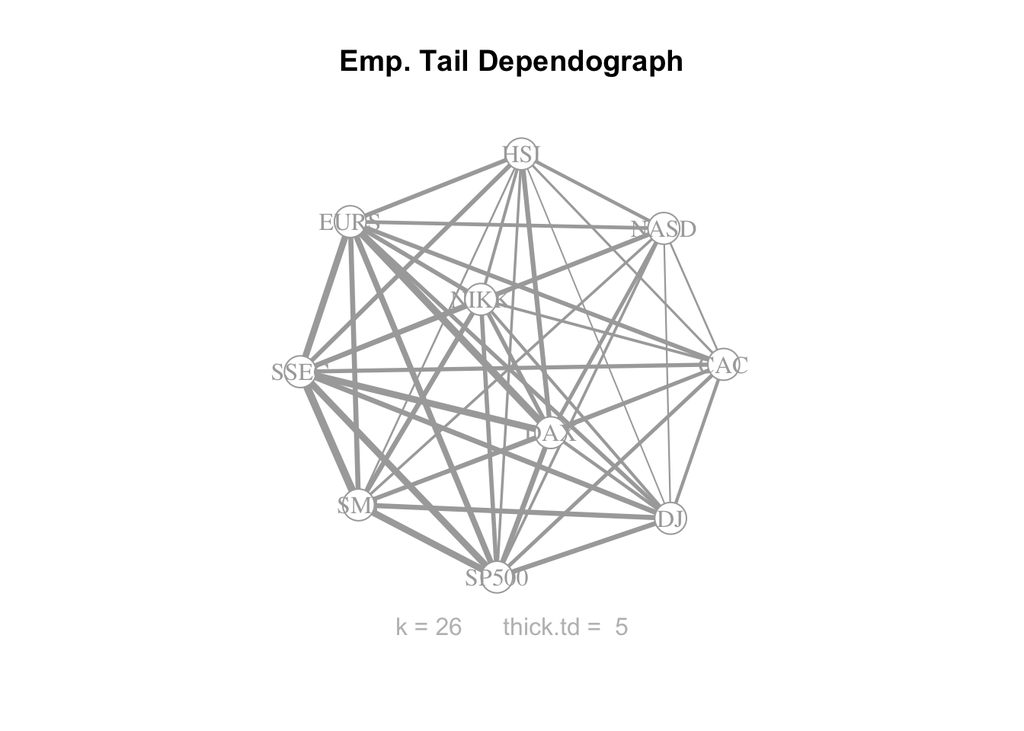

```r
## Figure 7(a) of Mercadier and Roustant (2019).
graphsEmp(Stock, k = 26, names = colnames(Stock), random = TRUE)
```

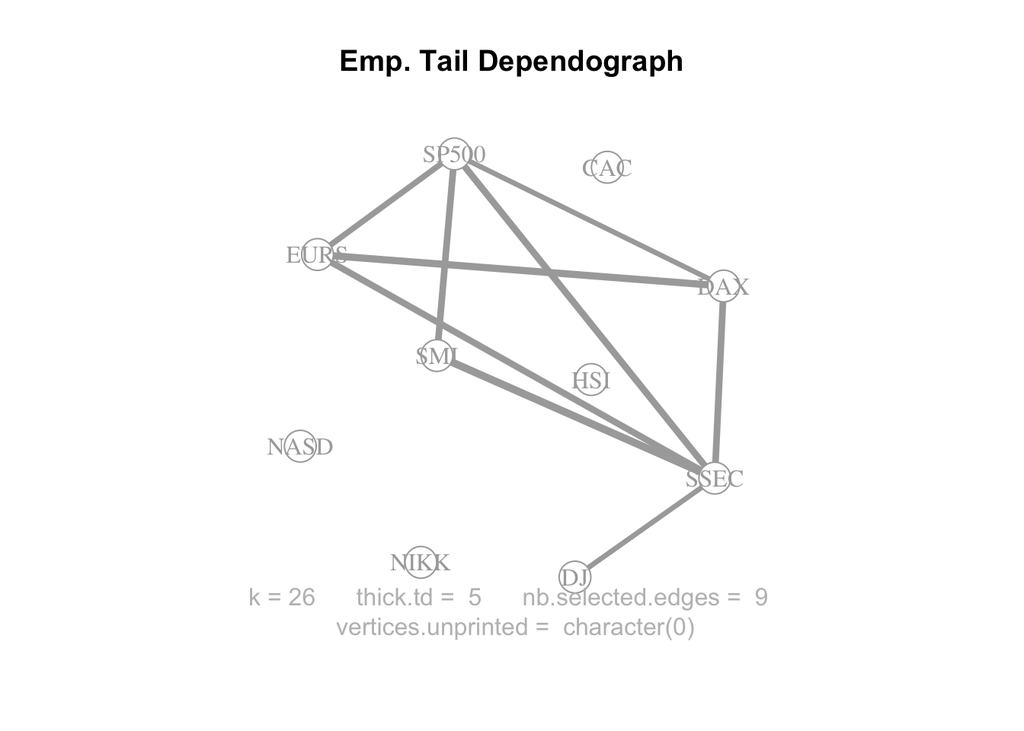

```r
## Figure 8(a) of Mercadier and Roustant (2019).
graphsEmp(Stock, k = 26, names = colnames(Stock), random = TRUE, select = 9)
```

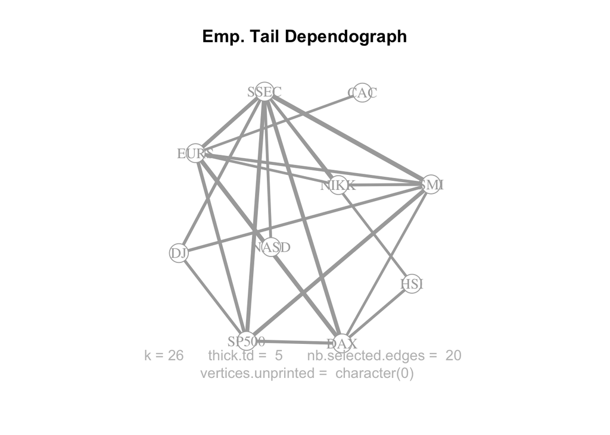

```r
## Figure 8(b) of Mercadier and Roustant (2019).
graphsEmp(Stock, k = 26, names = colnames(Stock), random = TRUE, select = 20)
```

# 4. Contents of the package `satdad`

More details on the package are given in the help pages associated with the following list of functions.

| **Method** | **Description** |
| --- | --- |
| `copArchimaxMevlog` | cop-ell-psi-psiinv- functions for Archimax Mevlog models. |
| `dMevlog` | r-p-d-ell- functions for Mevlog models. |
| `ec` | Extremal coefficients for Mevlog models. |
| `ecEmp` | Empirical Extremal coefficients. |
| `ellArchimaxMevlog` | cop-ell-psi-psiinv- functions for Archimax Mevlog models. |
| `ellEmp` | Empirical stable tail dependence function. |
| `ellMevlog` | r-p-d-ell- functions for Mevlog models. |
| `France` | Dataset. Yearly Maxima of Temperature and coordinates of 21 French cities 1946-2000. |
| `gen.ds` | Generate and check a Mevlog tail dependence structure. |
| `graphs` | Graphs of the tail dependence structure for Mevlog models. |
| `graphsEmp` | Empirical graphs of the tail dependence structure. |
| `graphsMapEmp` | Empirical graphs drawn on geographical maps of the tail dependence structure. |
| `plotClev` | Cleveland’s Dot Plots of the tail dependence structure. |
| `plotClevEmp` | Empirical Cleveland’s Dot Plots of the tail dependence structure. |
| `pMevlog` | r-p-d-ell- functions for Mevlog models. |
| `psiArchimaxMevlog` | cop-ell-psi-psiinv- functions for Archimax Mevlog models. |
| `psiinvArchimaxMevlog` | cop-ell-psi-psiinv- functions for Archimax Mevlog models. |
| `rArchimaxMevlog` | r function for Archimax Mevlog models. |
| `rMevlog` | r-p-d-ell- functions for Mevlog models. |
| `Stock` | Dataset. Yearly maxima of Log Returns of ten stock indices 1990-2015. |
| `tic` | Tail importance coefficients for Mevlog models. |
| `ticEmp` | Empirical tail importance coefficients. |
| `tsic` | Tail superset importance coefficients for Mevlog models. |
| `tsicEmp` | Empirical tail superset importance coefficients. |

If you have suggestions, or if you have encountered bugs, please contact me at mercadier@math.univ-lyon1.fr.

# 5. References

Asadi, P., Davison, A.C. and Engelke, S. (2015). *Extremes on river networks.* The Annals of Applied Statistics, 9(4), 2023–2050.

Becker, R. A., Wilks, A. R. (Original S code), Brownrigg, R. (R version), Minka, T. P. and Deckmyn A. (Enhancements). (2022) *maps : Draw Geographical Maps.* R package version 3.4.1.

Charpentier, A., Fougères, A.-L., Genest, C. and Nešlehová, J.G. (2014) *Multivariate Archimax copulas.* Journal of Multivariate Analysis, 126, 118–136.

Engelke, S. and Hitz, A.S. (2020). *Graphical models for extremes (with discussion).* J. R. Stat. Soc. Ser. B Stat. Methodol., 82, 871–932.

Fougères, A.-L., de Haan, L. and Mercadier, C. (2015). *Bias correction in multivariate extremes.* Annals of Statistics 43 (2), 903–934.

Gumbel, E. J. (1960) *Distributions des valeurs extremes en plusieurs dimensions.* Publ. Inst. Statist. Univ. Paris, **9**, 171–173.

de Haan, L. and Resnick, S. I. (1993). *Estimating the limit distribution of multivariate extremes. Communications in Statistics.* Stochastic Models 9, 275–309.

Huang, X. (1992). *Statistics of bivariate extremes.* PhD Thesis, Erasmus University Rotterdam, Tinbergen Institute Research series No. 22.

Liu, R. and Owen, A. B. (2006) *Estimating mean dimensionality of analysis of variance decompositions.* J. Amer. Statist. Assoc., **101**(474):712–721.

Mercadier, C. and Ressel, P. (2021) *Hoeffding–Sobol decomposition of homogeneous co-survival functions: from Choquet representation to extreme value theory application.* Dependence Modeling, **9**(1), 179–198.

Mercadier, C. and Roustant, O. (2019) *The tail dependograph.* Extremes, 22, 343–372.

Smith, R. L. (1990) *Max-stable processes and spatial extremes.* Dept. of Math., Univ. of Surrey, Guildford GU2 5XH, England.

Stephenson, A. (2002) *evd: Extreme Value Distributions.* R News, 2(2):31–32.

Stephenson, A. (2003) *Simulating Multivariate Extreme Value Distributions of Logistic Type.* Extremes, **6**, 49–59.

Tiago de Oliveira, J. (1962/63) *Structure theory of bivariate extremes, extensions.* Estudos de Matematica, Estatistica, e Economicos, 7:165–195.